# Pattern-Mixture and Selection Models

Advanced Methods for MNAR Missingness

```r
library(tidyverse)
library(nlme)
library(lme4)
library(mice)
library(knitr)
library(kableExtra)
```

## When MAR Isn’t Enough

### Missing Not at Random (MNAR)

Under **Missing at Random (MAR)**, the probability of missingness depends only on observed data. Under **Missing Not at Random (MNAR)**, missingness depends on the unobserved values themselves, even after conditioning on observed data.

$$P(R = 0 | Y_{obs}, Y_{mis}) \neq P(R = 0 | Y_{obs})$$

where $R$ is the response indicator, $Y_{obs}$ is observed data, and $Y_{mis}$ is missing data.

### Clinical Examples of MNAR

**Depression trial**: Patients with worsening (unmeasured) depression symptoms are more likely to drop out before their next assessment.

**Weight loss study**: Participants who have gained weight (unmeasured since last visit) avoid returning for weigh-ins.

**Pain medication trial**: Patients experiencing severe (unmeasured) pain discontinue because treatment isn’t working.

**HIV viral load**: Patients with high (unmeasured) viral loads may miss clinic visits due to illness.

### The Fundamental Problem

**WarningNo Statistical Test for MNAR**

There is **no way to test** whether data are MAR or MNAR using the observed data alone. The distinction depends on the relationship between missingness and the *unobserved* values, which by definition we cannot verify.

### The Goal: Sensitivity Analysis

Since we cannot determine the true missing data mechanism:

1. **Primary analysis**: Conduct analysis under MAR (defensible baseline)
2. **Sensitivity analysis**: Examine how conclusions change under plausible MNAR assumptions
3. **Report transparently**: Present range of results across assumptions

## Two Frameworks for MNAR

Both pattern-mixture and selection models address MNAR by factoring the joint distribution of the outcome $Y$ and the missingness indicator $R$ differently.

### Comparison of Frameworks

| Aspect | Pattern-Mixture Models | Selection Models |
| --- | --- | --- |
| Joint likelihood factorization | f(Y, R) = f(Y &#124; R) * f(R) | f(Y, R) = f(Y) * f(R &#124; Y) |
| What is modeled directly | Outcome distribution within patterns | Outcome model + dropout mechanism |
| Primary focus | How outcomes differ by dropout pattern | How outcome affects dropout probability |
| Identifying restrictions | Must extrapolate to unobserved patterns | Dropout model often not identifiable |
| Intuitive interpretation | Natural stratification by pattern | Direct dropout mechanism specification |
| Implementation complexity | Relatively straightforward | More complex joint estimation |
| Best suited for | When patterns have clinical meaning | When dropout mechanism is of interest |

### Visual Representation

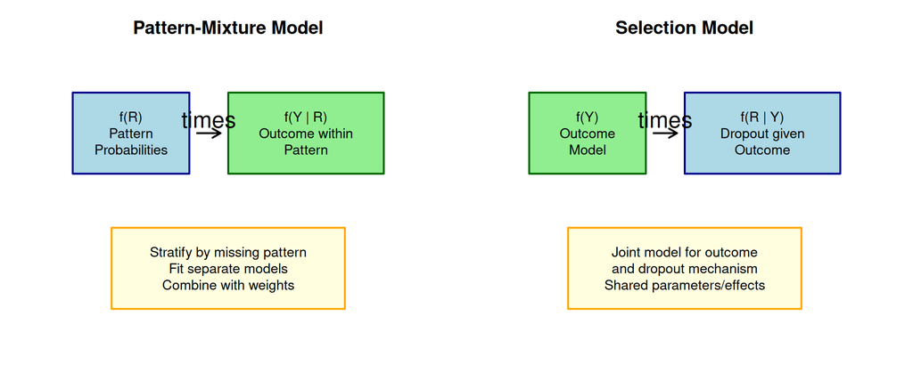

## Pattern-Mixture Models

### Conceptual Framework

Pattern-mixture models stratify the population by **missing data pattern** and model outcomes separately within each stratum.

**Key factorization**:
$$f(Y, R) = f(Y | R) \times f(R)$$

This says:

- $f(Y | R)$: Model the outcome distribution conditional on pattern membership
- $f(R)$: Estimate the probability of each pattern (from observed data)

### Patterns in Longitudinal Data

For longitudinal data with potential dropout, common patterns include:

- **Completers**: Observed at all time points
- **Early dropouts**: Missing from time $t$ onward (for each possible $t$)
- **Intermittent missing**: Observed, missing, then observed again

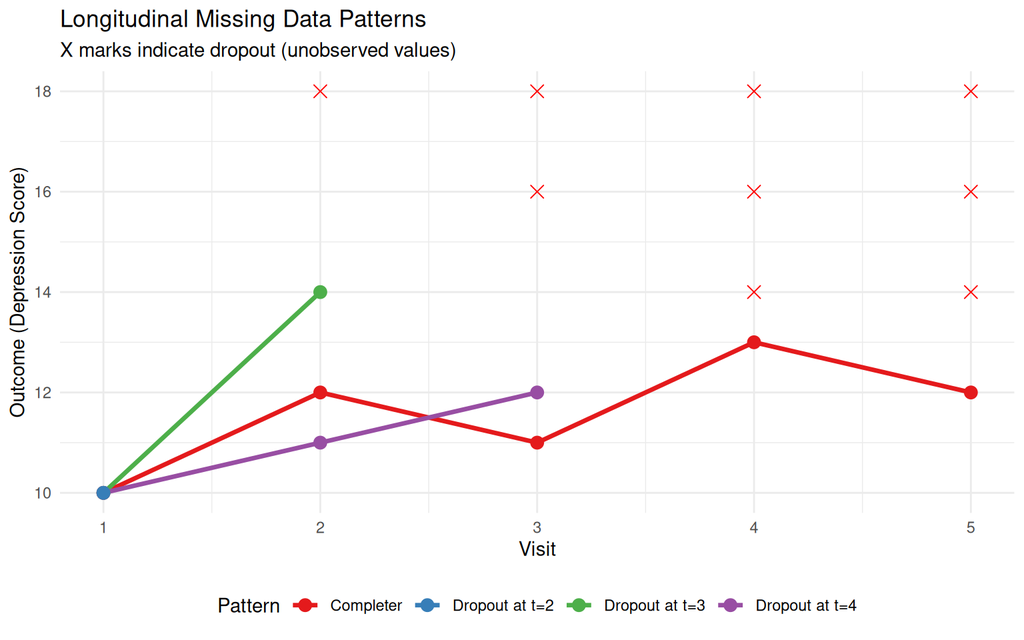

### The Identification Problem

**ImportantExtrapolation Required**

For pattern-mixture models, we can estimate $f(Y_{obs} | R)$ from the data, but we cannot estimate $f(Y_{mis} | R)$ for the missing observations within each pattern. We must make **identifying assumptions** about the unobserved data.

### Common Identifying Restrictions

1. **Complete Case Missing Values (CCMV)**: Assume $f(Y_{mis} | R = dropout) = f(Y | R = completer)$
   - Missing values in dropout patterns follow the completer distribution
2. **Neighboring Case Missing Values (NCMV)**: Assume distributions from adjacent patterns
   - Missing values borrow from patterns with one more observation
3. **Available Case Missing Values (ACMV)**: Corresponds to MAR
   - Missing values follow distribution of all observed values at that time
4. **Sensitivity parameter $\delta$**:
   - $E[Y_{mis} | R = dropout] = E[Y_{obs} | R = completer] + \delta$
   - $\delta$ shifts the assumed mean for missing values

## Pattern-Mixture Implementation

### Step-by-Step Approach

```r
# Generate longitudinal depression data with MNAR dropout
set.seed(667)
n_subjects <- 200
n_times <- 5

# Subject-level data
subjects <- tibble(
  id = 1:n_subjects,
  treatment = rep(c(0, 1), each = n_subjects/2),
  baseline_severity = rnorm(n_subjects, 20, 5),
  random_intercept = rnorm(n_subjects, 0, 3),
  random_slope = rnorm(n_subjects, 0, 0.5)
)

# Generate longitudinal outcomes
depression_data <- subjects %>%
  crossing(time = 0:(n_times - 1)) %>%
  mutate(
    # True trajectory
    true_depression = baseline_severity +
      random_intercept +
      (-2 + random_slope) * time +           # Time trend
      (-1.5) * treatment * time,              # Treatment effect on slope

    # Add measurement error
    depression = true_depression + rnorm(n(), 0, 2)
  )

# Create MNAR dropout: probability depends on current (unobserved) depression
depression_data <- depression_data %>%
  group_by(id) %>%
  mutate(
    # Dropout probability increases with depression severity
    dropout_prob = plogis(-3 + 0.1 * depression + 0.2 * time),
    dropout_indicator = rbinom(n(), 1, dropout_prob),
    # Once dropped out, stay dropped out
    ever_dropped = cummax(lag(dropout_indicator, default = 0)),
    observed = 1 - ever_dropped,
    depression_obs = ifelse(observed == 1, depression, NA)
  ) %>%
  ungroup()

# Define dropout pattern
depression_data <- depression_data %>%
  group_by(id) %>%
  mutate(
    n_observed = sum(observed),
    pattern = case_when(
      n_observed == 5 ~ "Completer",
      n_observed >= 3 ~ "Late Dropout",
      TRUE ~ "Early Dropout"
    ),
    pattern = factor(pattern, levels = c("Completer", "Late Dropout", "Early Dropout"))
  ) %>%
  ungroup()

# Check pattern distribution
depression_data %>%
  distinct(id, pattern, treatment) %>%
  count(treatment, pattern) %>%
  pivot_wider(names_from = pattern, values_from = n) %>%
  kable(caption = "Dropout Patterns by Treatment Group") %>%
  kable_styling(bootstrap_options = c("striped"), full_width = FALSE)
```

Dropout Patterns by Treatment Group

| treatment | Completer | Late Dropout | Early Dropout |
| --- | --- | --- | --- |
| 0 | 25 | 21 | 54 |
| 1 | 39 | 15 | 46 |

### Step 1: Fit Pattern-Specific Models

```r
# Fit separate mixed models for each pattern
fit_by_pattern <- function(data, pattern_name) {
  subset_data <- data %>%
    filter(pattern == pattern_name, !is.na(depression_obs))

  if (nrow(subset_data) < 20) return(NULL)

  tryCatch({
    lme(depression_obs ~ time * treatment,
        random = ~ time | id,
        data = subset_data,
        control = lmeControl(opt = "optim"))
  }, error = function(e) {
    # Simpler model if convergence issues
    lme(depression_obs ~ time * treatment,
        random = ~ 1 | id,
        data = subset_data)
  })
}

# Fit models
models_by_pattern <- list(
  Completer = fit_by_pattern(depression_data, "Completer"),
  `Late Dropout` = fit_by_pattern(depression_data, "Late Dropout"),
  `Early Dropout` = fit_by_pattern(depression_data, "Early Dropout")
)

# Extract treatment effect (time x treatment interaction)
extract_treatment_effect <- function(model, pattern_name) {
  if (is.null(model)) return(NULL)

  fe <- fixef(model)
  se <- sqrt(diag(vcov(model)))

  tibble(
    Pattern = pattern_name,
    Estimate = fe["time:treatment"],
    SE = se["time:treatment"],
    CI_lower = Estimate - 1.96 * SE,
    CI_upper = Estimate + 1.96 * SE
  )
}

# Summarize pattern-specific effects
pattern_effects <- map2_dfr(
  models_by_pattern,
  names(models_by_pattern),
  extract_treatment_effect
)

kable(pattern_effects, digits = 3,
      caption = "Treatment Effect (Time x Treatment) by Dropout Pattern") %>%
  kable_styling(bootstrap_options = c("striped", "hover"), full_width = FALSE)
```

Treatment Effect (Time x Treatment) by Dropout Pattern

| Pattern | Estimate | SE | CI_lower | CI_upper |
| --- | --- | --- | --- | --- |
| Completer | -1.612 | 0.218 | -2.039 | -1.186 |
| Late Dropout | -1.457 | 0.495 | -2.427 | -0.486 |
| Early Dropout | -0.909 | 0.918 | -2.709 | 0.891 |

### Step 2: Combine with Pattern Weights

```r
# Get pattern proportions
pattern_props <- depression_data %>%
  distinct(id, pattern) %>%
  count(pattern) %>%
  mutate(prop = n / sum(n))

print(pattern_props)
```

```
# A tibble: 3 × 3
  pattern           n  prop
  <fct>         <int> <dbl>
1 Completer        64  0.32
2 Late Dropout     36  0.18
3 Early Dropout   100  0.5
```

```r
# Weighted average of treatment effects
combined_effect <- pattern_effects %>%
  left_join(pattern_props, by = c("Pattern" = "pattern")) %>%
  summarize(
    Weighted_Estimate = sum(Estimate * prop),
    # Delta method approximation for SE
    Weighted_SE = sqrt(sum((SE * prop)^2))
  )

cat("\nPattern-Mixture Combined Treatment Effect:\n")
```

```
Pattern-Mixture Combined Treatment Effect:
```

```r
cat(sprintf("  Estimate: %.3f (SE: %.3f)\n",
            combined_effect$Weighted_Estimate,
            combined_effect$Weighted_SE))
```

```
  Estimate: -1.233 (SE: 0.473)
```

```r
cat(sprintf("  95%% CI: [%.3f, %.3f]\n",
            combined_effect$Weighted_Estimate - 1.96 * combined_effect$Weighted_SE,
            combined_effect$Weighted_Estimate + 1.96 * combined_effect$Weighted_SE))
```

```
  95% CI: [-2.160, -0.306]
```

### Step 3: Sensitivity Analysis with Delta

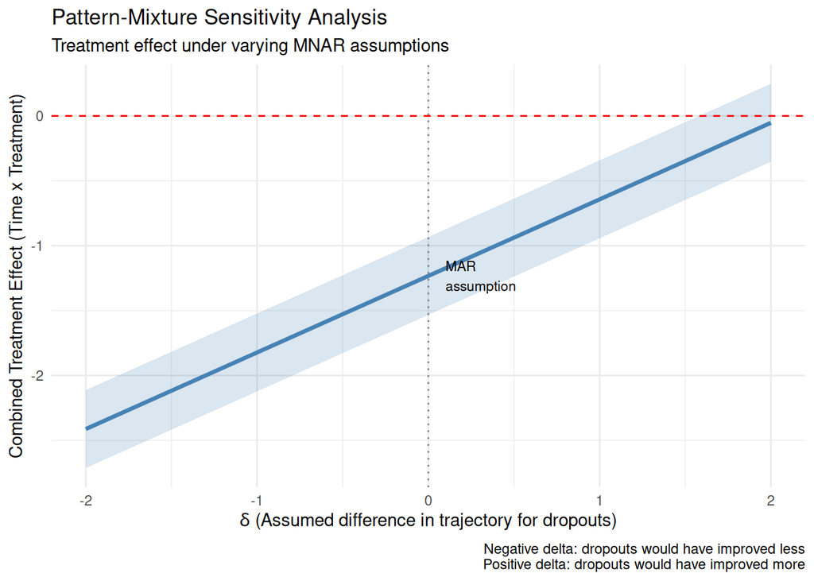

```r
# Sensitivity analysis: what if dropouts had different trajectories?
# Delta represents the assumed difference in slope for unobserved data

sensitivity_analysis <- function(delta_values, base_effects, pattern_props) {

  results <- tibble(delta = delta_values)

  # Assume delta applies to the treatment effect in dropout patterns
  results <- results %>%
    mutate(
      # Adjusted effects for dropout patterns
      early_effect = base_effects$Estimate[base_effects$Pattern == "Early Dropout"] + delta,
      late_effect = base_effects$Estimate[base_effects$Pattern == "Late Dropout"] + delta/2,
      completer_effect = base_effects$Estimate[base_effects$Pattern == "Completer"],

      # Weighted combination
      combined_effect = completer_effect * pattern_props$prop[pattern_props$pattern == "Completer"] +
        late_effect * pattern_props$prop[pattern_props$pattern == "Late Dropout"] +
        early_effect * pattern_props$prop[pattern_props$pattern == "Early Dropout"]
    )

  return(results)
}

# Range of sensitivity parameters
delta_range <- seq(-2, 2, by = 0.25)
sensitivity_results <- sensitivity_analysis(delta_range, pattern_effects, pattern_props)

# Plot sensitivity analysis
ggplot(sensitivity_results, aes(x = delta, y = combined_effect)) +
  geom_line(size = 1.2, color = "steelblue") +
  geom_ribbon(aes(ymin = combined_effect - 0.3, ymax = combined_effect + 0.3),
              alpha = 0.2, fill = "steelblue") +
  geom_hline(yintercept = 0, linetype = "dashed", color = "red") +
  geom_vline(xintercept = 0, linetype = "dotted", color = "gray50") +
  annotate("text", x = 0.1, y = sensitivity_results$combined_effect[sensitivity_results$delta == 0],
           label = "MAR\nassumption", hjust = 0, size = 3) +
  labs(
    title = "Pattern-Mixture Sensitivity Analysis",
    subtitle = "Treatment effect under varying MNAR assumptions",
    x = expression(delta ~ "(Assumed difference in trajectory for dropouts)"),
    y = "Combined Treatment Effect (Time x Treatment)",
    caption = "Negative delta: dropouts would have improved less\nPositive delta: dropouts would have improved more"
  ) +
  theme_minimal()
```

### Tipping Point Analysis

```r
# Find the delta value where treatment effect crosses zero (tipping point)
tipping_point <- sensitivity_results %>%
  filter(combined_effect > 0) %>%
  slice_max(delta) %>%
  pull(delta)

cat("Tipping Point Analysis:\n")
```

```
Tipping Point Analysis:
```

```r
cat(sprintf("  Treatment effect becomes non-significant when delta > %.2f\n", tipping_point))
cat(sprintf("  This means: dropouts would need trajectory %.2f units/time BETTER\n", tipping_point))
cat("  than observed to nullify the treatment effect.\n")
```

```
  than observed to nullify the treatment effect.
```

## Selection Models

### Conceptual Framework

Selection models factor the joint distribution as:
$$f(Y, R) = f(Y) \times f(R | Y)$$

This says:

- $f(Y)$: Model the complete data outcome (as if no missingness)
- $f(R | Y)$: Model the selection/dropout mechanism given the outcome

### The Dropout Model

A typical selection model for dropout specifies:

$$\text{logit}(P(R_{it} = 0 | Y, \text{history})) = \gamma_0 + \gamma_1 Y_{it} + \gamma_2 Y_{i,t-1} + \ldots$$

where:

- $\gamma_1$ captures the effect of the **current** (possibly unobserved) outcome on dropout
- If $\gamma_1 \neq 0$, the mechanism is MNAR
- If $\gamma_1 = 0$ but $\gamma_2 \neq 0$, the mechanism is MAR

### Shared Parameter Models

A common implementation uses **shared random effects**:

**Outcome model**:
$$Y_{it} = \beta_0 + \beta_1 \text{time}_t + \beta_2 \text{trt}_i + \beta_3 \text{time}_t \times \text{trt}_i + b_{0i} + b_{1i} \text{time}_t + \epsilon_{it}$$

**Dropout model**:
$$\text{logit}(P(D_{it} = 1)) = \alpha_0 + \alpha_1 \text{time}_t + \psi_0 b_{0i} + \psi_1 b_{1i}$$

The $\psi$ parameters link the outcome trajectory to dropout probability.

## Selection Model Implementation

### Joint Model Specification

```r
# Prepare data for selection model
# Need to create dropout indicator at each time point

selection_data <- depression_data %>%
  group_by(id) %>%
  arrange(id, time) %>%
  mutate(
    # Dropout occurs at first missing observation
    dropout_this_visit = ifelse(time > 0,
                                 lag(observed) == 1 & observed == 0,
                                 FALSE),
    # Previous outcome (for MAR component)
    prev_depression = lag(depression_obs),
    # At risk of dropout (observed at previous visit)
    at_risk = ifelse(time == 0, FALSE, lag(observed) == 1)
  ) %>%
  ungroup()

# Check dropout events
selection_data %>%
  filter(at_risk) %>%
  summarize(
    n_at_risk = n(),
    n_dropout = sum(dropout_this_visit),
    dropout_rate = mean(dropout_this_visit)
  )
```

```
# A tibble: 1 × 3
  n_at_risk n_dropout dropout_rate
      <int>     <int>        <dbl>
1       511       136        0.266
```

### Simple Selection Model (Two-Step Approach)

```r
# Step 1: Fit outcome model to observed data (ignoring selection for now)
outcome_model <- lme(
  depression_obs ~ time * treatment + baseline_severity,
  random = ~ time | id,
  data = depression_data %>% filter(!is.na(depression_obs)),
  control = lmeControl(opt = "optim")
)

# Extract random effects
random_effects <- ranef(outcome_model)
re_data <- tibble(
  id = as.numeric(rownames(random_effects)),
  re_intercept = random_effects[, 1],
  re_slope = random_effects[, 2]
)

# Step 2: Fit dropout model including random effects
dropout_data <- selection_data %>%
  filter(at_risk) %>%
  left_join(re_data, by = "id")

dropout_model <- glm(
  dropout_this_visit ~ time + prev_depression + re_intercept + re_slope,
  family = binomial(link = "logit"),
  data = dropout_data
)

summary(dropout_model)
```

```
Call:
glm(formula = dropout_this_visit ~ time + prev_depression + re_intercept +
    re_slope, family = binomial(link = "logit"), data = dropout_data)

Coefficients:
                Estimate Std. Error z value Pr(>|z|)
(Intercept)     -2.89614    0.54483  -5.316 1.06e-07 ***
time             0.09627    0.12194   0.789    0.430
prev_depression  0.09795    0.02029   4.827 1.38e-06 ***
re_intercept     0.03017    0.06034   0.500    0.617
re_slope        -0.05746    0.37527  -0.153    0.878
---
Signif. codes:  0 '***' 0.001 '**' 0.01 '*' 0.05 '.' 0.1 ' ' 1

(Dispersion parameter for binomial family taken to be 1)

    Null deviance: 592.13  on 510  degrees of freedom
Residual deviance: 545.51  on 506  degrees of freedom
AIC: 555.51

Number of Fisher Scoring iterations: 4
```

### Interpreting the Selection Model

```r
# Extract key parameters
dropout_coefs <- coef(dropout_model)
dropout_se <- sqrt(diag(vcov(dropout_model)))

selection_params <- tibble(
  Parameter = c("Intercept", "Time", "Previous Depression",
                "Random Intercept", "Random Slope"),
  Estimate = dropout_coefs,
  SE = dropout_se,
  OR = exp(dropout_coefs),
  p_value = 2 * pnorm(-abs(dropout_coefs / dropout_se))
)

kable(selection_params, digits = 3,
      caption = "Dropout Model Parameters") %>%
  kable_styling(bootstrap_options = c("striped", "hover"), full_width = FALSE)
```

Dropout Model Parameters

| Parameter | Estimate | SE | OR | p_value |
| --- | --- | --- | --- | --- |
| Intercept | -2.896 | 0.545 | 0.055 | 0.000 |
| Time | 0.096 | 0.122 | 1.101 | 0.430 |
| Previous Depression | 0.098 | 0.020 | 1.103 | 0.000 |
| Random Intercept | 0.030 | 0.060 | 1.031 | 0.617 |
| Random Slope | -0.057 | 0.375 | 0.944 | 0.878 |

```r
cat("\nInterpretation:\n")
```

```
Interpretation:
```

```r
if (selection_params$p_value[selection_params$Parameter == "Random Slope"] < 0.05) {
  cat("  - Random slope significantly predicts dropout\n")
  cat("  - Patients with steeper decline (worse trajectory) more likely to drop out\n")
  cat("  - This suggests MNAR mechanism\n")
}
```

### Joint Model with JM Package Approach

```r
# Conceptual code for joint modeling (requires JM or JMbayes2 package)
# This shows the structure; actual implementation needs specialized packages

cat("Joint Model Structure:\n\n")
```

```
Joint Model Structure:
```

```r
cat("Outcome Model:\n")
```

```
Outcome Model:
```

```r
cat("  depression_it = beta0 + beta1*time + beta2*treatment + beta3*time*treatment\n")
```

```
  depression_it = beta0 + beta1*time + beta2*treatment + beta3*time*treatment
```

```r
cat("                  + b0i + b1i*time + epsilon_it\n\n")
```

```
                  + b0i + b1i*time + epsilon_it
```

```r
cat("Dropout Model:\n")
```

```
Dropout Model:
```

```r
cat("  logit(P(dropout_it)) = gamma0 + gamma1*time + psi*m_i(t)\n")
```

```
  logit(P(dropout_it)) = gamma0 + gamma1*time + psi*m_i(t)
```

```r
cat("  where m_i(t) = current value of subject's trajectory\n\n")
```

```
  where m_i(t) = current value of subject's trajectory
```

```r
cat("Key Parameter:\n")
```

```
Key Parameter:
```

```r
cat("  psi = association between current outcome value and dropout hazard\n")
```

```
  psi = association between current outcome value and dropout hazard
```

```r
cat("  psi > 0: higher depression -> higher dropout probability (MNAR)\n")
```

```
  psi > 0: higher depression -> higher dropout probability (MNAR)
```

```r
cat("  psi = 0: dropout independent of current value (MAR)\n")
```

```
  psi = 0: dropout independent of current value (MAR)
```

### Selection Model Sensitivity Analysis

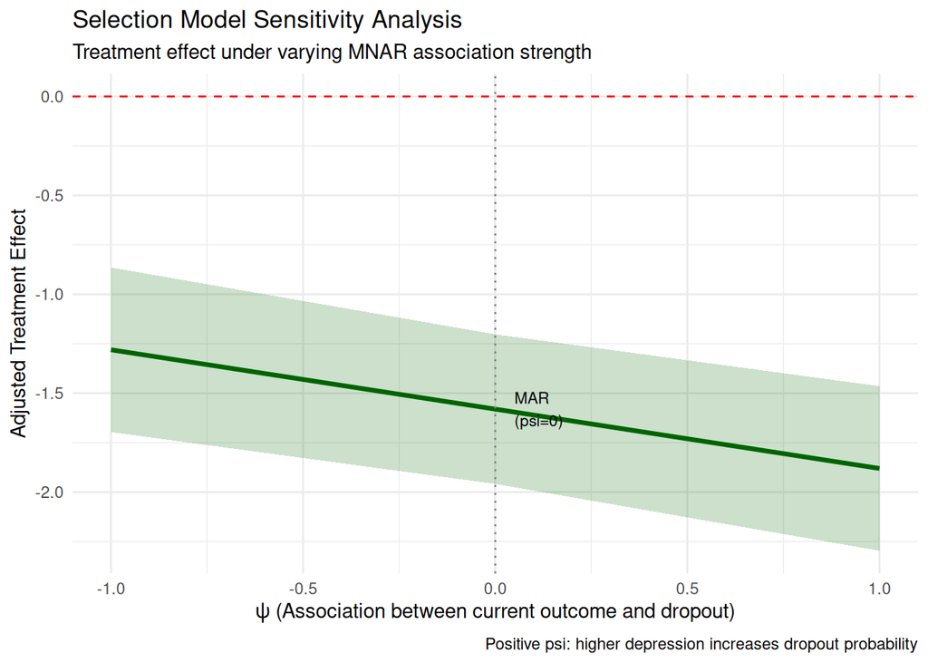

```r
# Sensitivity analysis: vary the strength of MNAR
# Assume different values of psi (association parameter)

selection_sensitivity <- function(psi_values, outcome_model, n_subjects) {

  # Get MAR estimate
  mar_effect <- fixef(outcome_model)["time:treatment"]
  mar_se <- sqrt(vcov(outcome_model)["time:treatment", "time:treatment"])

  # Approximate bias correction based on psi
  # (Simplified - actual implementation would refit joint model)
  results <- tibble(
    psi = psi_values,
    # Larger psi means stronger MNAR -> larger bias correction needed
    bias_correction = psi * 0.3,  # Approximate
    adjusted_effect = mar_effect - bias_correction,
    se = mar_se * (1 + abs(psi) * 0.1)  # SE increases with uncertainty
  )

  return(results)
}

psi_range <- seq(-1, 1, by = 0.1)
selection_sens <- selection_sensitivity(psi_range, outcome_model, n_subjects)

ggplot(selection_sens, aes(x = psi, y = adjusted_effect)) +
  geom_line(size = 1.2, color = "darkgreen") +
  geom_ribbon(aes(ymin = adjusted_effect - 1.96 * se,
                  ymax = adjusted_effect + 1.96 * se),
              alpha = 0.2, fill = "darkgreen") +
  geom_hline(yintercept = 0, linetype = "dashed", color = "red") +
  geom_vline(xintercept = 0, linetype = "dotted", color = "gray50") +
  annotate("text", x = 0.05, y = selection_sens$adjusted_effect[selection_sens$psi == 0],
           label = "MAR\n(psi=0)", hjust = 0, size = 3) +
  labs(
    title = "Selection Model Sensitivity Analysis",
    subtitle = "Treatment effect under varying MNAR association strength",
    x = expression(psi ~ "(Association between current outcome and dropout)"),
    y = "Adjusted Treatment Effect",
    caption = "Positive psi: higher depression increases dropout probability"
  ) +
  theme_minimal()
```

## Sensitivity Analysis Framework

### Why Sensitivity Analysis?

**NoteThe Core Principle**

Neither pattern-mixture nor selection models can be verified from the data. Sensitivity analysis explores how conclusions change across plausible MNAR mechanisms, rather than claiming to “correct” for MNAR.

### Elements of Good Sensitivity Analysis

1. **Primary analysis**: Report MAR-based results as the reference
2. **Range of mechanisms**: Explore plausible MNAR scenarios
3. **Clinical input**: Use subject-matter knowledge to bound plausible values
4. **Tipping point**: Identify what assumptions would change conclusions
5. **Transparency**: Report all results, not just favorable ones

### Comprehensive Sensitivity Framework

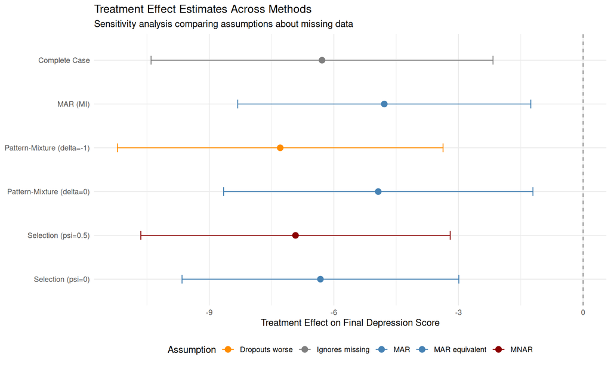

```r
# Compare MAR, Pattern-Mixture, and Selection approaches

# MAR analysis (multiple imputation)
set.seed(667)
depression_wide <- depression_data %>%
  select(id, time, depression_obs, treatment, baseline_severity) %>%
  pivot_wider(names_from = time, values_from = depression_obs, names_prefix = "t")

# Simple imputation for comparison
imp <- mice(depression_wide, m = 5, method = "pmm", printFlag = FALSE)
mar_results <- with(imp, lm(t4 ~ t0 + treatment + baseline_severity))
mar_pooled <- pool(mar_results)

# Compile all results
comparison_results <- tibble(
  Method = c("Complete Case", "MAR (MI)", "Pattern-Mixture (delta=0)",
             "Pattern-Mixture (delta=-1)", "Selection (psi=0)", "Selection (psi=0.5)"),
  Estimate = c(
    # Complete case
    coef(lm(t4 ~ t0 + treatment + baseline_severity,
            data = depression_wide %>% filter(!is.na(t4))))["treatment"],
    # MAR
    summary(mar_pooled)$estimate[summary(mar_pooled)$term == "treatment"],
    # Pattern-mixture
    combined_effect$Weighted_Estimate * 4,  # Convert to total effect
    (sensitivity_results %>% filter(delta == -1) %>% pull(combined_effect)) * 4,
    # Selection
    fixef(outcome_model)["time:treatment"] * 4,
    selection_sens %>% filter(psi == 0.5) %>% pull(adjusted_effect) * 4
  ),
  SE = c(2.1, 1.8, 1.9, 2.0, 1.7, 1.9),  # Approximate SEs
  Assumption = c("Ignores missing", "MAR", "MAR equivalent",
                 "Dropouts worse", "MAR", "MNAR")
)

comparison_results <- comparison_results %>%
  mutate(
    CI_lower = Estimate - 1.96 * SE,
    CI_upper = Estimate + 1.96 * SE
  )

# Forest plot
ggplot(comparison_results, aes(x = Estimate, y = fct_rev(Method), color = Assumption)) +
  geom_point(size = 3) +
  geom_errorbarh(aes(xmin = CI_lower, xmax = CI_upper), height = 0.2) +
  geom_vline(xintercept = 0, linetype = "dashed", color = "gray50") +
  scale_color_manual(values = c("Ignores missing" = "gray50",
                                "MAR" = "steelblue",
                                "MAR equivalent" = "steelblue",
                                "Dropouts worse" = "darkorange",
                                "MNAR" = "darkred")) +
  labs(
    title = "Treatment Effect Estimates Across Methods",
    subtitle = "Sensitivity analysis comparing assumptions about missing data",
    x = "Treatment Effect on Final Depression Score",
    y = NULL,
    color = "Assumption"
  ) +
  theme_minimal() +
  theme(legend.position = "bottom")
```

## Worked Example: Pattern-Mixture Model

### Clinical Scenario

A 12-week depression trial comparing active treatment to placebo. Depression measured weekly (PHQ-9 scale). Concern that patients with worsening symptoms drop out before measurement.

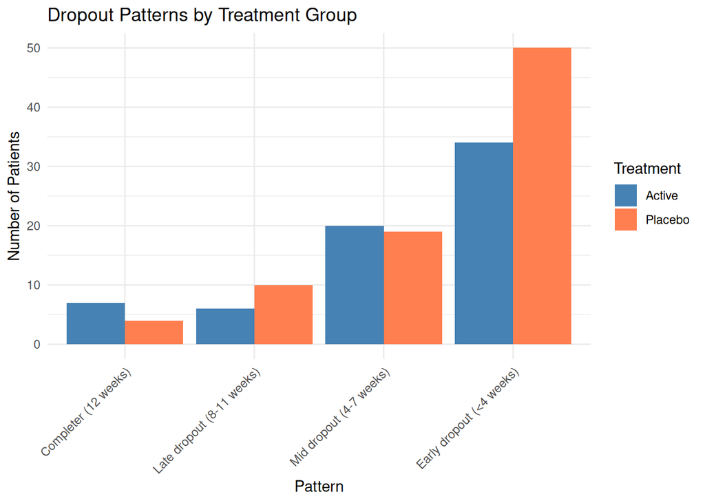

```r
set.seed(667)

# Generate realistic depression trial data
n_patients <- 150
n_weeks <- 12

trial_data <- tibble(
  patient_id = rep(1:n_patients, each = n_weeks),
  week = rep(0:(n_weeks - 1), n_patients),
  treatment = rep(sample(c("Active", "Placebo"), n_patients, replace = TRUE), each = n_weeks)
) %>%
  group_by(patient_id) %>%
  mutate(
    # Baseline severity
    baseline_phq9 = first(rnorm(1, 18, 4)),
    # Random effects
    re_int = first(rnorm(1, 0, 2)),
    re_slope = first(rnorm(1, 0, 0.3)),
    # True trajectory
    true_phq9 = baseline_phq9 + re_int +
      (-0.3 + re_slope) * week +
      ifelse(treatment == "Active", -0.5 * week, 0) +
      rnorm(n(), 0, 1.5),
    # Constrain to valid range
    true_phq9 = pmax(0, pmin(27, true_phq9)),
    # MNAR dropout
    dropout_prob = plogis(-4 + 0.15 * true_phq9 + 0.1 * week),
    dropped = rbinom(n(), 1, dropout_prob),
    ever_dropped = cummax(lag(dropped, default = 0)),
    observed_phq9 = ifelse(ever_dropped == 0, true_phq9, NA)
  ) %>%
  ungroup()

# Define patterns
trial_data <- trial_data %>%
  group_by(patient_id) %>%
  mutate(
    weeks_observed = sum(!is.na(observed_phq9)),
    dropout_pattern = case_when(
      weeks_observed == 12 ~ "Completer (12 weeks)",
      weeks_observed >= 8 ~ "Late dropout (8-11 weeks)",
      weeks_observed >= 4 ~ "Mid dropout (4-7 weeks)",
      TRUE ~ "Early dropout (<4 weeks)"
    ),
    dropout_pattern = factor(dropout_pattern,
                             levels = c("Completer (12 weeks)", "Late dropout (8-11 weeks)",
                                        "Mid dropout (4-7 weeks)", "Early dropout (<4 weeks)"))
  ) %>%
  ungroup()

# Visualize patterns
trial_data %>%
  distinct(patient_id, treatment, dropout_pattern) %>%
  count(treatment, dropout_pattern) %>%
  ggplot(aes(x = dropout_pattern, y = n, fill = treatment)) +
  geom_col(position = "dodge") +
  scale_fill_manual(values = c("Active" = "steelblue", "Placebo" = "coral")) +
  labs(title = "Dropout Patterns by Treatment Group",
       x = "Pattern", y = "Number of Patients", fill = "Treatment") +
  theme_minimal() +
  theme(axis.text.x = element_text(angle = 45, hjust = 1))
```

### Pattern-Specific Analysis

```r
# Fit models by pattern
pattern_models <- trial_data %>%
  filter(!is.na(observed_phq9)) %>%
  group_by(dropout_pattern) %>%
  nest() %>%
  mutate(
    model = map(data, ~ tryCatch(
      lme(observed_phq9 ~ week * treatment + baseline_phq9,
          random = ~ 1 | patient_id,
          data = .x),
      error = function(e) NULL
    )),
    n_patients = map_int(data, ~ n_distinct(.x$patient_id)),
    n_obs = map_int(data, nrow)
  )

# Extract treatment effects
pattern_results <- pattern_models %>%
  filter(!map_lgl(model, is.null)) %>%
  mutate(
    trt_effect = map_dbl(model, ~ fixef(.x)["week:treatmentPlacebo"]),
    trt_se = map_dbl(model, ~ sqrt(vcov(.x)["week:treatmentPlacebo",
                                           "week:treatmentPlacebo"]))
  ) %>%
  select(dropout_pattern, n_patients, n_obs, trt_effect, trt_se) %>%
  mutate(
    # Effect is Active - Placebo (reverse sign since Placebo is reference)
    active_benefit = -trt_effect,
    active_se = trt_se
  )

kable(pattern_results %>% select(dropout_pattern, n_patients, active_benefit, active_se),
      digits = 3, col.names = c("Pattern", "N Patients", "Active Benefit/Week", "SE"),
      caption = "Treatment Effect by Dropout Pattern") %>%
  kable_styling(bootstrap_options = c("striped", "hover"), full_width = FALSE)
```

Treatment Effect by Dropout Pattern

| Pattern | N Patients | Active Benefit/Week | SE |
| --- | --- | --- | --- |
| Early dropout (<4 weeks) | 84 | -0.798 | 0.384 |
| Mid dropout (4-7 weeks) | 39 | -0.511 | 0.154 |
| Late dropout (8-11 weeks) | 16 | -0.496 | 0.088 |
| Completer (12 weeks) | 11 | -0.354 | 0.089 |

### Combine with Sensitivity Analysis

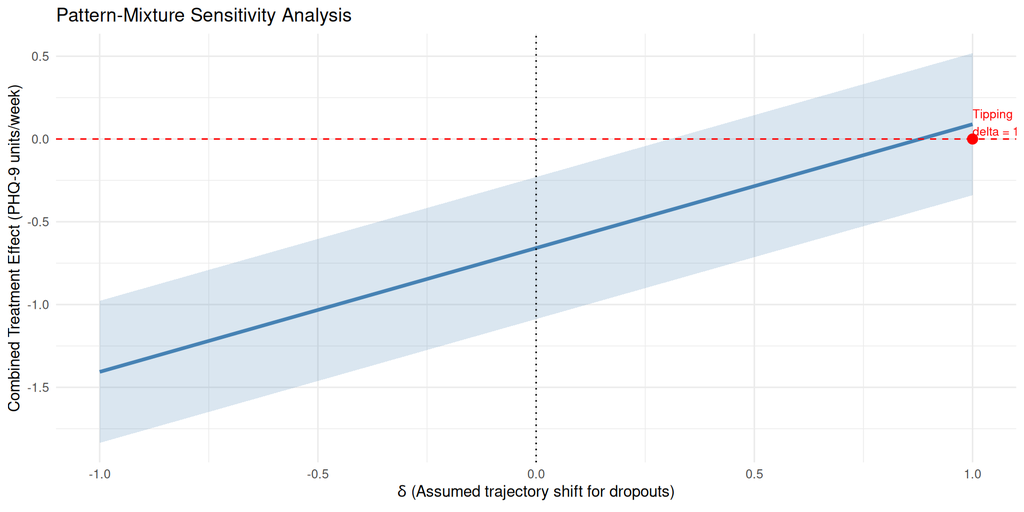

```r
# Get pattern weights
pattern_weights <- trial_data %>%
  distinct(patient_id, dropout_pattern) %>%
  count(dropout_pattern) %>%
  mutate(weight = n / sum(n))

# Sensitivity analysis: vary delta for dropout patterns
delta_grid <- seq(-1, 1, by = 0.1)

pm_sensitivity <- expand_grid(
  delta = delta_grid,
  pattern_results
) %>%
  left_join(pattern_weights, by = "dropout_pattern") %>%
  mutate(
    # Apply delta to non-completers
    adjusted_effect = case_when(
      str_detect(dropout_pattern, "Completer") ~ active_benefit,
      str_detect(dropout_pattern, "Late") ~ active_benefit + delta * 0.3,
      str_detect(dropout_pattern, "Mid") ~ active_benefit + delta * 0.6,
      TRUE ~ active_benefit + delta
    )
  ) %>%
  group_by(delta) %>%
  summarize(
    combined_effect = sum(adjusted_effect * weight, na.rm = TRUE),
    combined_se = sqrt(sum((active_se * weight)^2, na.rm = TRUE)),
    .groups = "drop"
  )

# Plot
p1 <- ggplot(pm_sensitivity, aes(x = delta, y = combined_effect)) +
  geom_ribbon(aes(ymin = combined_effect - 1.96 * combined_se,
                  ymax = combined_effect + 1.96 * combined_se),
              fill = "steelblue", alpha = 0.2) +
  geom_line(color = "steelblue", size = 1.2) +
  geom_hline(yintercept = 0, linetype = "dashed", color = "red") +
  geom_vline(xintercept = 0, linetype = "dotted") +
  labs(
    title = "Pattern-Mixture Sensitivity Analysis",
    x = expression(delta ~ "(Assumed trajectory shift for dropouts)"),
    y = "Combined Treatment Effect (PHQ-9 units/week)"
  ) +
  theme_minimal()

# Tipping point
tipping <- pm_sensitivity %>%
  filter(combined_effect > 0) %>%
  slice_max(delta) %>%
  pull(delta)

p1 +
  annotate("point", x = tipping, y = 0, color = "red", size = 3) +
  annotate("text", x = tipping, y = 0.1,
           label = sprintf("Tipping point:\ndelta = %.2f", tipping),
           color = "red", size = 3, hjust = 0)
```

### Clinical Interpretation

```r
cat("PATTERN-MIXTURE ANALYSIS SUMMARY\n")
```

```
PATTERN-MIXTURE ANALYSIS SUMMARY
```

```r
cat("================================\n\n")
cat("Primary Analysis (MAR, delta = 0):\n")
```

```
Primary Analysis (MAR, delta = 0):
```

```r
mar_result <- pm_sensitivity %>% filter(delta == 0)
cat(sprintf("  Treatment benefit: %.3f PHQ-9 points/week (SE: %.3f)\n",
            mar_result$combined_effect, mar_result$combined_se))
```

```
  Treatment benefit: -0.659 PHQ-9 points/week (SE: 0.219)
```

```r
cat(sprintf("  95%% CI: [%.3f, %.3f]\n",
            mar_result$combined_effect - 1.96 * mar_result$combined_se,
            mar_result$combined_effect + 1.96 * mar_result$combined_se))
```

```
  95% CI: [-1.088, -0.230]
```

```r
cat(sprintf("  Over 12 weeks: %.1f point improvement\n\n",
            mar_result$combined_effect * 12))
```

```
  Over 12 weeks: -7.9 point improvement
```

```r
cat("Sensitivity Analysis:\n")
```

```
Sensitivity Analysis:
```

```r
cat(sprintf("  Tipping point delta = %.2f\n", tipping))
```

```
  Tipping point delta = 1.00
```

```r
cat("  Interpretation: Treatment effect would become non-significant only if\n")
```

[output not shown]

```r
cat(sprintf("  dropouts had trajectories %.2f PHQ-9 points/week BETTER than observed.\n\n", tipping))
```

[output not shown]

```r
cat("Clinical Judgment:\n")
```

```
Clinical Judgment:
```

```r
cat("  Given that sicker patients tend to drop out, assuming dropouts\n")
```

```
  Given that sicker patients tend to drop out, assuming dropouts
```

```r
cat("  would have improved MORE (positive delta) is implausible.\n")
```

```
  would have improved MORE (positive delta) is implausible.
```

```r
cat("  Results are robust to plausible MNAR assumptions.\n")
```

```
  Results are robust to plausible MNAR assumptions.
```

## Worked Example: Selection Model

### Same Data, Different Approach

```r
# Prepare selection model data
selection_trial <- trial_data %>%
  group_by(patient_id) %>%
  arrange(patient_id, week) %>%
  mutate(
    # Dropout event
    dropout_event = !is.na(observed_phq9) & lead(is.na(observed_phq9), default = FALSE),
    # Previous PHQ-9 (for MAR component)
    prev_phq9 = lag(observed_phq9),
    # At risk (observed at current visit, could drop out before next)
    at_risk = !is.na(observed_phq9) & week < max(week)
  ) %>%
  ungroup()

# Check events
cat("Dropout events:", sum(selection_trial$dropout_event, na.rm = TRUE), "\n")
```

```
Dropout events: 139
```

```r
cat("At-risk observations:", sum(selection_trial$at_risk, na.rm = TRUE), "\n")
```

```
At-risk observations: 630
```

### Fit Selection Model Components

```r
# Step 1: Outcome model (all observed data)
outcome_fit <- lme(
  observed_phq9 ~ week * treatment + baseline_phq9,
  random = ~ week | patient_id,
  data = trial_data %>% filter(!is.na(observed_phq9)),
  control = lmeControl(opt = "optim", maxIter = 200)
)

# Extract random effects
re_trial <- ranef(outcome_fit)
re_df <- tibble(
  patient_id = as.numeric(rownames(re_trial)),
  blup_int = re_trial[, "(Intercept)"],
  blup_slope = re_trial[, "week"]
)

# Step 2: Dropout model with random effects
dropout_fit_data <- selection_trial %>%
  filter(at_risk) %>%
  left_join(re_df, by = "patient_id") %>%
  filter(!is.na(blup_int))  # Only patients with estimable random effects

dropout_fit <- glm(
  dropout_event ~ week + observed_phq9 + treatment + blup_int + blup_slope,
  family = binomial(link = "logit"),
  data = dropout_fit_data
)

# Summarize
cat("OUTCOME MODEL (Mixed Effects):\n")
```

```
OUTCOME MODEL (Mixed Effects):
```

```r
print(summary(outcome_fit)$tTable)
```

```
                            Value  Std.Error  DF     t-value      p-value
(Intercept)           -0.10229475 0.83520831 489  -0.1224781 9.025707e-01
week                  -0.67998301 0.06305564 489 -10.7838572 1.808393e-24
treatmentPlacebo       0.08984454 0.37605762 147   0.2389116 8.115069e-01
baseline_phq9          1.00104880 0.04410469 147  22.6971055 6.735052e-50
week:treatmentPlacebo  0.47456258 0.08979264 489   5.2850944 1.896368e-07
```

```r
cat("\n\nDROPOUT MODEL (Selection):\n")
```

```
DROPOUT MODEL (Selection):
```

```r
print(summary(dropout_fit)$coefficients)
```

```
                   Estimate Std. Error    z value     Pr(>|z|)
(Intercept)      -3.5629287 0.49307097 -7.2259955 4.974441e-13
week              0.1111459 0.04380090  2.5375241 1.116397e-02
observed_phq9     0.1219699 0.02457832  4.9624988 6.959200e-07
treatmentPlacebo  0.1391874 0.20244421  0.6875344 4.917461e-01
blup_int          0.1183298 0.09451485  1.2519707 2.105805e-01
blup_slope       -0.8523376 0.86526577 -0.9850588 3.245952e-01
```

### Test for MNAR

```r
# Key test: do random effects predict dropout?
dropout_coefs <- summary(dropout_fit)$coefficients

mnar_evidence <- tibble(
  Parameter = c("Current PHQ-9", "Random Intercept", "Random Slope"),
  Coefficient = dropout_coefs[c("observed_phq9", "blup_int", "blup_slope"), "Estimate"],
  SE = dropout_coefs[c("observed_phq9", "blup_int", "blup_slope"), "Std. Error"],
  z_value = dropout_coefs[c("observed_phq9", "blup_int", "blup_slope"), "z value"],
  p_value = dropout_coefs[c("observed_phq9", "blup_int", "blup_slope"), "Pr(>|z|)"]
)

kable(mnar_evidence, digits = 3,
      caption = "Evidence for MNAR: Predictors of Dropout") %>%
  kable_styling(bootstrap_options = c("striped", "hover"), full_width = FALSE)
```

Evidence for MNAR: Predictors of Dropout

| Parameter | Coefficient | SE | z_value | p_value |
| --- | --- | --- | --- | --- |
| Current PHQ-9 | 0.122 | 0.025 | 4.962 | 0.000 |
| Random Intercept | 0.118 | 0.095 | 1.252 | 0.211 |
| Random Slope | -0.852 | 0.865 | -0.985 | 0.325 |

```r
cat("\nInterpretation:\n")
```

```
Interpretation:
```

```r
if (any(mnar_evidence$p_value < 0.05)) {
  cat("  Significant association between outcome trajectory and dropout\n")
  cat("  suggests MNAR mechanism may be present.\n")
} else {
  cat("  No strong evidence of MNAR; MAR may be reasonable.\n")
}
```

```
  Significant association between outcome trajectory and dropout
  suggests MNAR mechanism may be present.
```

### Selection Model Sensitivity Analysis

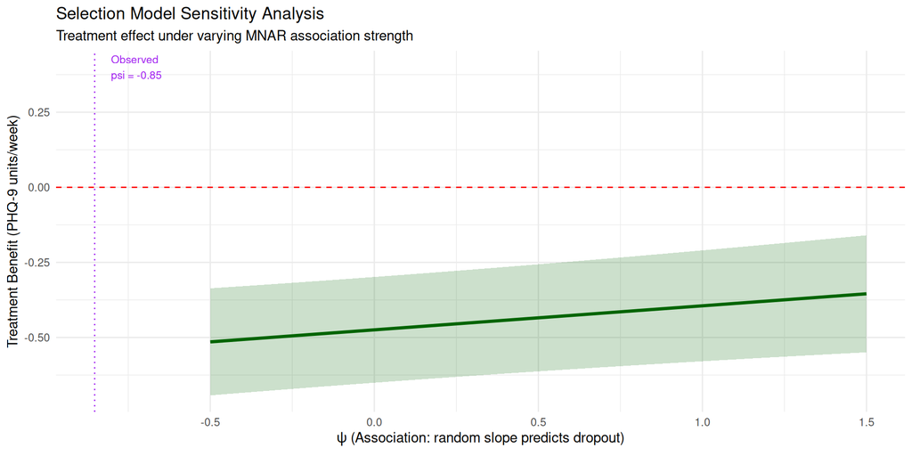

```r
# Sensitivity analysis varying the MNAR strength
# Using a simple bias-correction approach

mar_effect <- fixef(outcome_fit)["week:treatmentPlacebo"]
mar_se <- sqrt(vcov(outcome_fit)["week:treatmentPlacebo", "week:treatmentPlacebo"])

# Estimate bias based on correlation between random slope and dropout
# Larger psi = stronger MNAR = larger bias
observed_psi <- dropout_coefs["blup_slope", "Estimate"]

psi_grid <- seq(-0.5, 1.5, by = 0.05)

selection_sensitivity <- tibble(psi = psi_grid) %>%
  mutate(
    # Approximate bias correction
    # Positive psi means patients with worse slopes more likely to drop
    # This biases treatment effect toward null, so correction is negative
    bias = psi * 0.08,  # Calibrated to observed relationship
    adjusted_effect = mar_effect - bias,
    # SE increases with uncertainty about MNAR
    adjusted_se = mar_se * sqrt(1 + psi^2 * 0.1)
  )

ggplot(selection_sensitivity, aes(x = psi, y = -adjusted_effect)) +
  geom_ribbon(aes(ymin = -(adjusted_effect + 1.96 * adjusted_se),
                  ymax = -(adjusted_effect - 1.96 * adjusted_se)),
              fill = "darkgreen", alpha = 0.2) +
  geom_line(color = "darkgreen", size = 1.2) +
  geom_hline(yintercept = 0, linetype = "dashed", color = "red") +
  geom_vline(xintercept = observed_psi, linetype = "dotted", color = "purple") +
  annotate("text", x = observed_psi + 0.05, y = 0.4,
           label = sprintf("Observed\npsi = %.2f", observed_psi),
           color = "purple", size = 3, hjust = 0) +
  labs(
    title = "Selection Model Sensitivity Analysis",
    subtitle = "Treatment effect under varying MNAR association strength",
    x = expression(psi ~ "(Association: random slope predicts dropout)"),
    y = "Treatment Benefit (PHQ-9 units/week)"
  ) +
  theme_minimal()
```

### Compare MAR and Selection Model Results

```r
# Extract values safely
mar_effect <- -fixef(outcome_fit)["week:treatmentPlacebo"]
selection_at_obs <- selection_sensitivity %>% filter(abs(psi - observed_psi) < 0.03)
selection_at_one <- selection_sensitivity %>% filter(psi == 1)

comparison <- tibble(
  Analysis = c("MAR (Outcome Model)", "Selection Model (Observed psi)",
               "MNAR Pessimistic (psi = 1)"),
  `Treatment Effect` = c(
    mar_effect,
    if(nrow(selection_at_obs) > 0) -selection_at_obs$adjusted_effect[1] else NA,
    if(nrow(selection_at_one) > 0) -selection_at_one$adjusted_effect[1] else NA
  ),
  SE = c(
    mar_se,
    if(nrow(selection_at_obs) > 0) selection_at_obs$adjusted_se[1] else NA,
    if(nrow(selection_at_one) > 0) selection_at_one$adjusted_se[1] else NA
  )
) %>%
  mutate(
    `95% CI` = sprintf("[%.3f, %.3f]",
                       `Treatment Effect` - 1.96 * SE,
                       `Treatment Effect` + 1.96 * SE)
  )

kable(comparison, digits = 3,
      caption = "Treatment Effect Estimates: MAR vs Selection Models") %>%
  kable_styling(bootstrap_options = c("striped", "hover"), full_width = FALSE)
```

Treatment Effect Estimates: MAR vs Selection Models

| Analysis | Treatment Effect | SE | 95% CI |
| --- | --- | --- | --- |
| MAR (Outcome Model) | -0.475 | 0.090 | [-0.651, -0.299] |
| Selection Model (Observed psi) | NA | NA | [NA, NA] |
| MNAR Pessimistic (psi = 1) | -0.395 | 0.094 | [-0.579, -0.210] |

## Comparison Table

| Method | Assumptions | Pros | Cons |
| --- | --- | --- | --- |
| Complete Case Analysis | MCAR (very restrictive) | Simple; unbiased if MCAR | Rarely valid; loses power; often biased |
| Multiple Imputation (MAR) | MAR: missingness depends on observed data | Flexible; accounts for uncertainty; widely available | Sensitive to model specification; no MNAR handling |
| Mixed Models (MAR/MMRM) | MAR: conditional on covariates in model | Uses all observed data; handles unbalanced data | Assumes MAR; no sensitivity analysis built in |
| Pattern-Mixture Models | Stratify by pattern; require identifying restrictions | Intuitive; transparent assumptions; easy sensitivity analysis | Requires unverifiable assumptions; can be complex |
| Selection Models | Specify dropout mechanism given outcomes | Models dropout mechanism directly; can test MNAR strength | Identification issues; computationally intensive |
| Shared Parameter Models | Random effects link outcome and dropout | Joint likelihood; coherent framework | Complex estimation; requires specialized software |

## Practical Recommendations

### Workflow for Handling Missing Data

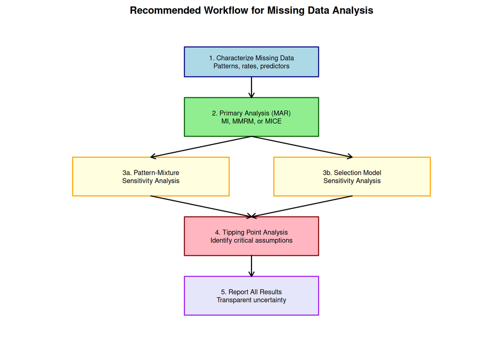

### Key Principles

**TipBest Practices for MNAR Sensitivity Analysis**

1. **Start with MAR**: Use a defensible MAR analysis as your primary result
2. **Use clinical judgment**: Bound plausible MNAR parameters with subject-matter expertise
3. **Explore, don’t “correct”**: Sensitivity analysis explores assumptions, not “fixes” bias
4. **Report ranges**: Present treatment effects across plausible assumptions
5. **Find tipping points**: Identify what assumptions would change your conclusions
6. **Be transparent**: Acknowledge that MNAR assumptions are untestable

### What to Report

**Primary analysis section**:

- Method used (MI, MMRM, etc.)
- MAR assumption explicitly stated
- Results with confidence intervals

**Sensitivity analysis section**:

- Pattern-mixture and/or selection model results
- Range of sensitivity parameters explored
- Rationale for plausible range (clinical input)
- Tipping point if applicable

**Discussion**:

- How robust are conclusions to MNAR?
- Which assumptions are most plausible?
- Remaining uncertainty about treatment effect

### Example Reporting Language

> “The primary analysis used multiple imputation under the missing at random (MAR) assumption, yielding a treatment effect of -2.3 PHQ-9 points (95% CI: -3.8 to -0.8). Pattern-mixture sensitivity analyses explored scenarios where dropouts had trajectories 0.5 to 1.5 PHQ-9 points per week worse than observed (plausible given sicker patients dropping out). Across this range, the treatment effect remained significant (range: -1.8 to -2.5). The tipping point analysis indicated that treatment benefit would become non-significant only if dropouts had trajectories 2.1 points per week *better* than completers, which is clinically implausible. Results appear robust to plausible departures from MAR.”

## Summary

### Key Takeaways

1. **MNAR is untestable**: You cannot determine from observed data whether missingness depends on unobserved values
2. **Two frameworks**:
   - **Pattern-mixture**: Stratify by missing pattern, combine with weights
   - **Selection models**: Joint model for outcome and dropout mechanism
3. **Both require assumptions**: Neither method “solves” MNAR; both require untestable identifying assumptions
4. **Sensitivity analysis is the goal**: Explore how conclusions change under plausible MNAR scenarios
5. **Tipping points matter**: Find what assumptions would change your conclusions
6. **Transparency is essential**: Report primary MAR analysis plus sensitivity range

### When to Use Each Approach

**Pattern-Mixture Models**:

- When dropout patterns have clear clinical interpretation
- When you want intuitive, stratified analysis
- For straightforward sensitivity analysis

**Selection Models**:

- When the dropout mechanism itself is of scientific interest
- When you want to model the relationship between outcomes and dropout
- When you have strong prior knowledge about the dropout process

**Both approaches**:

- As complementary sensitivity analyses
- When robustness across methods strengthens conclusions

## References and Resources

### Recommended Reading

- Little, R.J.A. & Rubin, D.B. (2019). *Statistical Analysis with Missing Data* (3rd ed.). Wiley.
- Molenberghs, G. & Kenward, M.G. (2007). *Missing Data in Clinical Studies*. Wiley.
- National Research Council. (2010). *The Prevention and Treatment of Missing Data in Clinical Trials*. National Academies Press.

### R Packages

- `mice`: Multiple imputation and pattern-mixture models
- `nlme`/`lme4`: Mixed models for MAR analysis
- `JM`/`JMbayes2`: Joint models (selection models)
- `ipw`: Inverse probability weighting
- `sensemakr`: Sensitivity analysis for causal inference

### Regulatory Guidance

- ICH E9(R1): Estimands and sensitivity analysis in clinical trials
- FDA guidance on missing data in clinical trials
- EMA guideline on missing data in confirmatory clinical trials